# Predicting Term Deposit Suscriptions

[figure not shown]

```python
from IPython.display import Image
Image("G:/ML portfolio projects/Own Projects\Predicting Term Deposit Suscriptions/1.png")
```

## Data Exploration and Preprocessing

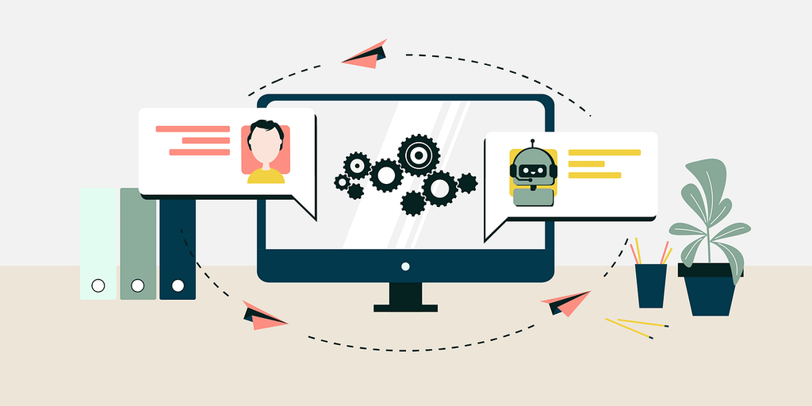

```python
Image("G:/ML portfolio projects/Own Projects\Predicting Term Deposit Suscriptions/3.png")
```

- Import the required libraries

```python
import pandas as pd
import numpy as np
import matplotlib.pyplot as plt
import seaborn as sns
```

- Load the dataset into a Pandas DataFrame

```python
df = pd.read_csv('bank.csv')
```

- Inspect the first few rows of the DataFrame to get a glimpse of the data

```python
df.head()
```

|  | age | job | marital | education | default | balance | housing | loan | contact | day | month | duration | campaign | pdays | previous | poutcome | deposit |
| --- | --- | --- | --- | --- | --- | --- | --- | --- | --- | --- | --- | --- | --- | --- | --- | --- | --- |
| 0 | 59 | admin. | married | secondary | no | 2343 | yes | no | unknown | 5 | may | 1042 | 1 | -1 | 0 | unknown | yes |
| 1 | 56 | admin. | married | secondary | no | 45 | no | no | unknown | 5 | may | 1467 | 1 | -1 | 0 | unknown | yes |
| 2 | 41 | technician | married | secondary | no | 1270 | yes | no | unknown | 5 | may | 1389 | 1 | -1 | 0 | unknown | yes |
| 3 | 55 | services | married | secondary | no | 2476 | yes | no | unknown | 5 | may | 579 | 1 | -1 | 0 | unknown | yes |
| 4 | 54 | admin. | married | tertiary | no | 184 | no | no | unknown | 5 | may | 673 | 2 | -1 | 0 | unknown | yes |

- Handle missing values:

Identify missing values in the dataset

```python
df.isnull().sum()
```

```
age          0
job          0
marital      0
education    0
default      0
balance      0
housing      0
loan         0
contact      0
day          0
month        0
duration     0
campaign     0
pdays        0
previous     0
poutcome     0
deposit      0
dtype: int64
```

- Encode categorical variables:

Identify categorical columns-

```python
categorical_cols = df.select_dtypes(include=['object']).columns
```

- Convert categorical variables into numerical representations using one-hot encoding or label encoding. For one-hot encoding

```python
df_encoded = pd.get_dummies(df, columns=categorical_cols, drop_first=True)
```

- Perform exploratory data analysis (EDA):

Inspect the first few rows of the DataFrame to get a glimpse of the data

```python
df_encoded.head()
```

|  | age | balance | day | duration | campaign | pdays | previous | job_blue-collar | job_entrepreneur | job_housemaid | ... | month_jun | month_mar | month_may | month_nov | month_oct | month_sep | poutcome_other | poutcome_success | poutcome_unknown | deposit_yes |
| --- | --- | --- | --- | --- | --- | --- | --- | --- | --- | --- | --- | --- | --- | --- | --- | --- | --- | --- | --- | --- | --- |
| 0 | 59 | 2343 | 5 | 1042 | 1 | -1 | 0 | 0 | 0 | 0 | ... | 0 | 0 | 1 | 0 | 0 | 0 | 0 | 0 | 1 | 1 |
| 1 | 56 | 45 | 5 | 1467 | 1 | -1 | 0 | 0 | 0 | 0 | ... | 0 | 0 | 1 | 0 | 0 | 0 | 0 | 0 | 1 | 1 |
| 2 | 41 | 1270 | 5 | 1389 | 1 | -1 | 0 | 0 | 0 | 0 | ... | 0 | 0 | 1 | 0 | 0 | 0 | 0 | 0 | 1 | 1 |
| 3 | 55 | 2476 | 5 | 579 | 1 | -1 | 0 | 0 | 0 | 0 | ... | 0 | 0 | 1 | 0 | 0 | 0 | 0 | 0 | 1 | 1 |
| 4 | 54 | 184 | 5 | 673 | 2 | -1 | 0 | 0 | 0 | 0 | ... | 0 | 0 | 1 | 0 | 0 | 0 | 0 | 0 | 1 | 1 |

5 rows × 43 columns

- Check the dimensions of the dataset (number of rows and columns)

```python
df_encoded.shape
```

```
(11162, 43)
```

- Explore the summary statistics of numerical features

```python
df_encoded.describe()
```

|  | age | balance | day | duration | campaign | pdays | previous | job_blue-collar | job_entrepreneur | job_housemaid | ... | month_jun | month_mar | month_may | month_nov | month_oct | month_sep | poutcome_other | poutcome_success | poutcome_unknown | deposit_yes |
| --- | --- | --- | --- | --- | --- | --- | --- | --- | --- | --- | --- | --- | --- | --- | --- | --- | --- | --- | --- | --- | --- |
| count | 11162.000000 | 11162.000000 | 11162.000000 | 11162.000000 | 11162.000000 | 11162.000000 | 11162.000000 | 11162.000000 | 11162.000000 | 11162.000000 | ... | 11162.000000 | 11162.000000 | 11162.000000 | 11162.000000 | 11162.000000 | 11162.000000 | 11162.000000 | 11162.000000 | 11162.000000 | 11162.000000 |
| mean | 41.231948 | 1528.538524 | 15.658036 | 371.993818 | 2.508421 | 51.330407 | 0.832557 | 0.174162 | 0.029385 | 0.024548 | ... | 0.109479 | 0.024727 | 0.253001 | 0.084483 | 0.035119 | 0.028579 | 0.048110 | 0.095951 | 0.745924 | 0.473840 |
| std | 11.913369 | 3225.413326 | 8.420740 | 347.128386 | 2.722077 | 108.758282 | 2.292007 | 0.379266 | 0.168892 | 0.154749 | ... | 0.312253 | 0.155298 | 0.434751 | 0.278123 | 0.184089 | 0.166628 | 0.214008 | 0.294537 | 0.435360 | 0.499338 |
| min | 18.000000 | -6847.000000 | 1.000000 | 2.000000 | 1.000000 | -1.000000 | 0.000000 | 0.000000 | 0.000000 | 0.000000 | ... | 0.000000 | 0.000000 | 0.000000 | 0.000000 | 0.000000 | 0.000000 | 0.000000 | 0.000000 | 0.000000 | 0.000000 |
| 25% | 32.000000 | 122.000000 | 8.000000 | 138.000000 | 1.000000 | -1.000000 | 0.000000 | 0.000000 | 0.000000 | 0.000000 | ... | 0.000000 | 0.000000 | 0.000000 | 0.000000 | 0.000000 | 0.000000 | 0.000000 | 0.000000 | 0.000000 | 0.000000 |
| 50% | 39.000000 | 550.000000 | 15.000000 | 255.000000 | 2.000000 | -1.000000 | 0.000000 | 0.000000 | 0.000000 | 0.000000 | ... | 0.000000 | 0.000000 | 0.000000 | 0.000000 | 0.000000 | 0.000000 | 0.000000 | 0.000000 | 1.000000 | 0.000000 |
| 75% | 49.000000 | 1708.000000 | 22.000000 | 496.000000 | 3.000000 | 20.750000 | 1.000000 | 0.000000 | 0.000000 | 0.000000 | ... | 0.000000 | 0.000000 | 1.000000 | 0.000000 | 0.000000 | 0.000000 | 0.000000 | 0.000000 | 1.000000 | 1.000000 |
| max | 95.000000 | 81204.000000 | 31.000000 | 3881.000000 | 63.000000 | 854.000000 | 58.000000 | 1.000000 | 1.000000 | 1.000000 | ... | 1.000000 | 1.000000 | 1.000000 | 1.000000 | 1.000000 | 1.000000 | 1.000000 | 1.000000 | 1.000000 | 1.000000 |

8 rows × 43 columns

- Check the data types of each column

```python
df_encoded.dtypes
```

```
age                    int64
balance                int64
day                    int64
duration               int64
campaign               int64
pdays                  int64
previous               int64
job_blue-collar        uint8
job_entrepreneur       uint8
job_housemaid          uint8
job_management         uint8
job_retired            uint8
job_self-employed      uint8
job_services           uint8
job_student            uint8
job_technician         uint8
job_unemployed         uint8
job_unknown            uint8
marital_married        uint8
marital_single         uint8
education_secondary    uint8
education_tertiary     uint8
education_unknown      uint8
default_yes            uint8
housing_yes            uint8
loan_yes               uint8
contact_telephone      uint8
contact_unknown        uint8
month_aug              uint8
month_dec              uint8
month_feb              uint8
month_jan              uint8
month_jul              uint8
month_jun              uint8
month_mar              uint8
month_may              uint8
month_nov              uint8
month_oct              uint8
month_sep              uint8
poutcome_other         uint8
poutcome_success       uint8
poutcome_unknown       uint8
deposit_yes            uint8
dtype: object
```

- Analyze the distribution of the target variable ('deposit_yes' column)

```python
deposit_yes['deposit_yes'].value_counts()
```

[output not shown]

- Visualize the distribution of the target variable using a bar plot

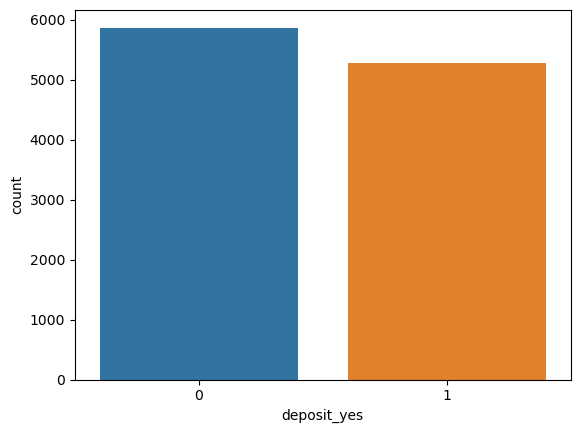

```python
sns.countplot(x='deposit_yes', data=df_encoded)
plt.show()
```

- Split the dataset into training and testing sets

```python
from sklearn.model_selection import train_test_split

X = df_encoded.drop('deposit_yes', axis=1)  # Features (excluding the target variable)
y = df_encoded['deposit_yes']  # Target variable

X_train, X_test, y_train, y_test = train_test_split(X, y, test_size=0.2, random_state=42)
```

## Model Selection and Training

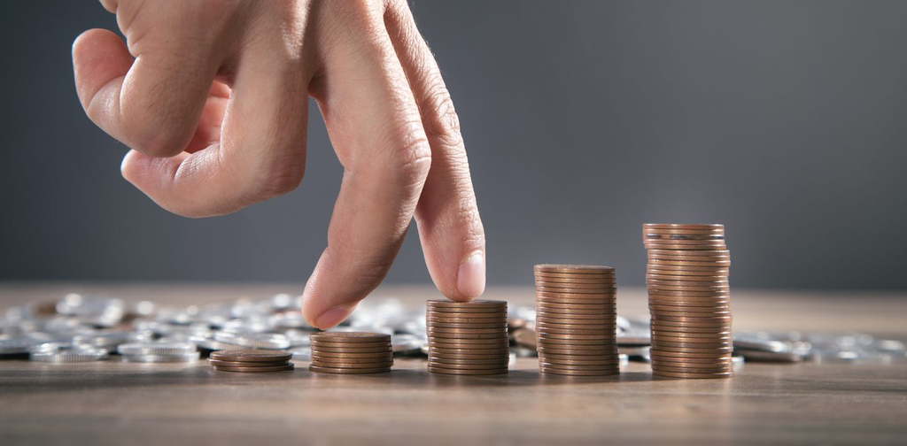

```python
Image("G:/ML portfolio projects/Own Projects\Predicting Term Deposit Suscriptions/4.jpg")
```

- Import the necessary libraries

```python
from sklearn.linear_model import LogisticRegression
from sklearn.tree import DecisionTreeClassifier
from sklearn.ensemble import RandomForestClassifier, GradientBoostingClassifier
from sklearn.svm import SVC
from sklearn.metrics import accuracy_score, precision_score, recall_score, f1_score, roc_auc_score
```

- Initialize the models

```python
logistic_regression = LogisticRegression()
decision_tree = DecisionTreeClassifier()
random_forest = RandomForestClassifier()
gradient_boosting = GradientBoostingClassifier()
support_vector_machine = SVC()
```

- Train the models on the training set

```python
logistic_regression.fit(X_train, y_train)
```

```
LogisticRegression()
```

```python
decision_tree.fit(X_train, y_train)
```

```
DecisionTreeClassifier()
```

```python
random_forest.fit(X_train, y_train)
```

```
RandomForestClassifier()
```

```python
gradient_boosting.fit(X_train, y_train)
```

```
GradientBoostingClassifier()
```

```python
support_vector_machine.fit(X_train, y_train)
```

```
SVC()
```

- Make predictions on the training set

```python
logistic_regression_train_preds = logistic_regression.predict(X_train)
decision_tree_train_preds = decision_tree.predict(X_train)
random_forest_train_preds = random_forest.predict(X_train)
gradient_boosting_train_preds = gradient_boosting.predict(X_train)
support_vector_machine_train_preds = support_vector_machine.predict(X_train)
```

- Evaluate the performance of each model on the training set

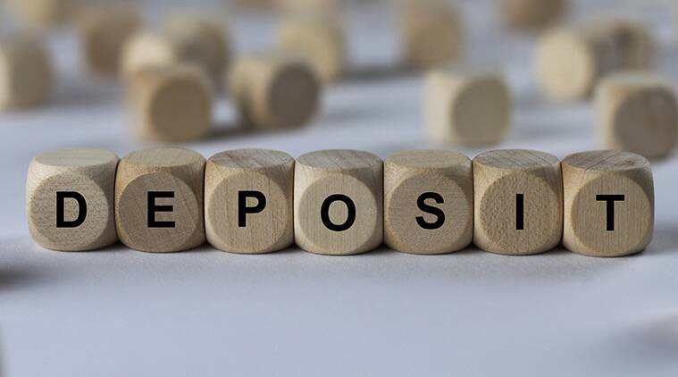

```python
Image("G:/ML portfolio projects/Own Projects\Predicting Term Deposit Suscriptions/5.jpg")
```

```python
print("Training Set Metrics:")
print("Logistic Regression:")
print("Accuracy:", accuracy_score(y_train, logistic_regression_train_preds))
print("Precision:", precision_score(y_train, logistic_regression_train_preds))
print("Recall:", recall_score(y_train, logistic_regression_train_preds))
print("F1-Score:", f1_score(y_train, logistic_regression_train_preds))
print("ROC-AUC:", roc_auc_score(y_train, logistic_regression_train_preds))

# Repeat the same evaluation steps for the other models
```

```
Training Set Metrics:
Logistic Regression:
Accuracy: 0.8007615634449546
Precision: 0.7691121392377176
Recall: 0.8268593083846518
F1-Score: 0.7969409884716357
ROC-AUC: 0.8021060935379813
```

```python
print("Training Set Metrics:")
print("Decision Tree:")
print("Accuracy:", accuracy_score(y_train, decision_tree_train_preds))
print("Precision:", precision_score(y_train, decision_tree_train_preds))
print("Recall:", recall_score(y_train, decision_tree_train_preds))
print("F1-Score:", f1_score(y_train, decision_tree_train_preds))
print("ROC-AUC:", roc_auc_score(y_train, decision_tree_train_preds))
```

[output not shown]

```python
print("Training Set Metrics:")
print("Random Forest:")
print("Accuracy:", accuracy_score(y_train, random_forest_train_preds))
print("Precision:", precision_score(y_train, random_forest_train_preds))
print("Recall:", recall_score(y_train, random_forest_train_preds))
print("F1-Score:", f1_score(y_train, random_forest_train_preds))
print("ROC-AUC:", roc_auc_score(y_train, random_forest_train_preds))
```

```
Training Set Metrics:
Random Forest:
Accuracy: 1.0
Precision: 1.0
Recall: 1.0
F1-Score: 1.0
ROC-AUC: 1.0
```

```python
print("Training Set Metrics:")
print("Gradient Boosting:")
print("Accuracy:", accuracy_score(y_train, gradient_boosting_train_preds))
print("Precision:", precision_score(y_train, gradient_boosting_train_preds))
print("Recall:", recall_score(y_train, gradient_boosting_train_preds))
print("F1-Score:", f1_score(y_train, gradient_boosting_train_preds))
print("ROC-AUC:", roc_auc_score(y_train, gradient_boosting_train_preds))
```

```
Training Set Metrics:
Gradient Boosting:
Accuracy: 0.8625825960353903
Precision: 0.8404182768811094
Recall: 0.8756513500710563
F1-Score: 0.8576731237675443
ROC-AUC: 0.863255885360576
```

```python
print("Training Set Metrics:")
print("Support Vector Machine:")
print("Accuracy:", accuracy_score(y_train, support_vector_machine_train_preds))
print("Precision:", precision_score(y_train, support_vector_machine_train_preds))
print("Recall:", recall_score(y_train, support_vector_machine_train_preds))
print("F1-Score:", f1_score(y_train, support_vector_machine_train_preds))
print("ROC-AUC:", roc_auc_score(y_train, support_vector_machine_train_preds))
```

```
Training Set Metrics:
Support Vector Machine:
Accuracy: 0.7437562996976145
Precision: 0.7814318975552969
Recall: 0.6359545239223117
F1-Score: 0.7012274745364325
ROC-AUC: 0.7382024584769833
```

## Model Evaluation and Comparison

[figure not shown]

```python
Image("G:/ML portfolio projects/Own Projects\Predicting Term Deposit Suscriptions/6.jpg")
```

- Import the necessary libraries

```python
from sklearn.metrics import accuracy_score, precision_score, recall_score, f1_score, roc_auc_score
```

- Define a list to store the evaluation metrics for each model

```python
models = [logistic_regression, decision_tree, random_forest, gradient_boosting, support_vector_machine]
model_names = ['Logistic Regression', 'Decision Tree', 'Random Forest', 'Gradient Boosting', 'Support Vector Machine']
accuracy_scores = []
precision_scores = []
recall_scores = []
f1_scores = []
roc_auc_scores = []
```

- Iterate over the models to evaluate their performance on the test set

```python
for model in models:
    preds = model.predict(X_test)
    accuracy_scores.append(accuracy_score(y_test, preds))
    precision_scores.append(precision_score(y_test, preds))
    recall_scores.append(recall_score(y_test, preds))
    f1_scores.append(f1_score(y_test, preds))
    roc_auc_scores.append(roc_auc_score(y_test, preds))
```

- Create a dataframe to compare the evaluation metrics of different models

```python
evaluation_df = pd.DataFrame({
    'Model': model_names,
    'Accuracy': accuracy_scores,
    'Precision': precision_scores,
    'Recall': recall_scores,
    'F1-Score': f1_scores,
    'ROC-AUC': roc_auc_scores
})
```

- Print or visualize the evaluation metrics for model comparison

```python
print(evaluation_df)
```

```
                    Model  Accuracy  Precision    Recall  F1-Score   ROC-AUC
0     Logistic Regression  0.786386   0.756522  0.815370  0.784844  0.787616
1           Decision Tree  0.789521   0.780809  0.777882  0.779343  0.789027
2           Random Forest  0.837438   0.808772  0.864105  0.835523  0.838570
3       Gradient Boosting  0.831169   0.815934  0.835052  0.825382  0.831334
4  Support Vector Machine  0.726825   0.750823  0.641050  0.691608  0.723183
```

- create visualizations such as bar plots or line plots to compare the evaluation metrics of different models.

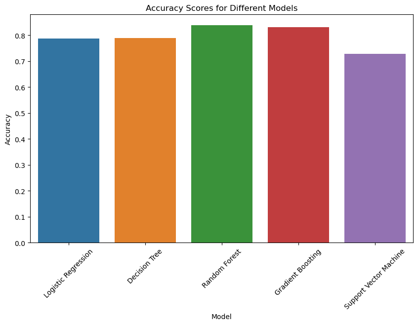

```python
plt.figure(figsize=(10, 6))
sns.barplot(x='Model', y='Accuracy', data=evaluation_df)
plt.xlabel('Model')
plt.ylabel('Accuracy')
plt.title('Accuracy Scores for Different Models')
plt.xticks(rotation=45)
plt.show()
```

- Logistic Regression

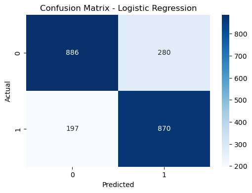

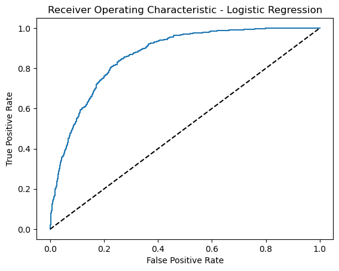

```python
from sklearn.metrics import confusion_matrix
import seaborn as sns

preds = logistic_regression.predict(X_test)
cm = confusion_matrix(y_test, preds)

plt.figure(figsize=(6, 4))
sns.heatmap(cm, annot=True, cmap='Blues', fmt='d')
plt.xlabel('Predicted')
plt.ylabel('Actual')
plt.title('Confusion Matrix - Logistic Regression')
plt.show()

from sklearn.metrics import roc_curve

preds = logistic_regression.predict_proba(X_test)[:, 1]  # Probability of positive class
fpr, tpr, thresholds = roc_curve(y_test, preds)

plt.plot(fpr, tpr)
plt.plot([0, 1], [0, 1], 'k--')  # Diagonal line for random classifier
plt.xlabel('False Positive Rate')
plt.ylabel('True Positive Rate')
plt.title('Receiver Operating Characteristic - Logistic Regression')
plt.show()
```

- Decision Tree

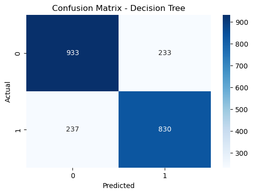

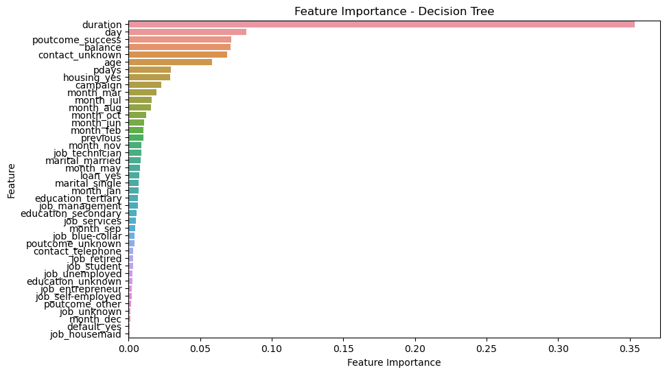

```python
from sklearn.metrics import confusion_matrix
import seaborn as sns

preds = decision_tree.predict(X_test)
cm = confusion_matrix(y_test, preds)

plt.figure(figsize=(6, 4))
sns.heatmap(cm, annot=True, cmap='Blues', fmt='d')
plt.xlabel('Predicted')
plt.ylabel('Actual')
plt.title('Confusion Matrix - Decision Tree')
plt.show()

feature_importances = decision_tree.feature_importances_
feature_names = X.columns

feature_importance_df = pd.DataFrame({'Feature': feature_names, 'Importance': feature_importances})
feature_importance_df = feature_importance_df.sort_values('Importance', ascending=False)

plt.figure(figsize=(10, 6))
sns.barplot(x='Importance', y='Feature', data=feature_importance_df)
plt.xlabel('Feature Importance')
plt.ylabel('Feature')
plt.title('Feature Importance - Decision Tree')
plt.show()
```

- Random Forest

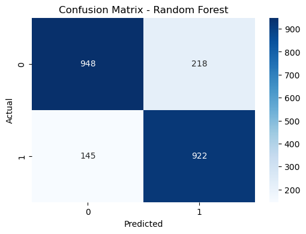

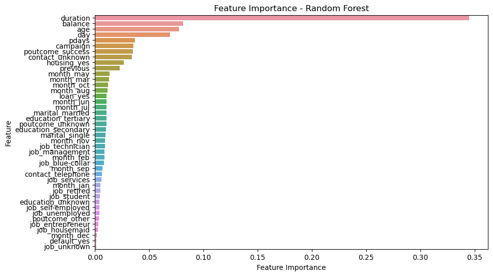

```python
from sklearn.metrics import confusion_matrix
import seaborn as sns

preds = random_forest.predict(X_test)
cm = confusion_matrix(y_test, preds)

plt.figure(figsize=(6, 4))
sns.heatmap(cm, annot=True, cmap='Blues', fmt='d')
plt.xlabel('Predicted')
plt.ylabel('Actual')
plt.title('Confusion Matrix - Random Forest')
plt.show()

feature_importances = random_forest.feature_importances_
feature_names = X.columns

feature_importance_df = pd.DataFrame({'Feature': feature_names, 'Importance': feature_importances})
feature_importance_df = feature_importance_df.sort_values('Importance', ascending=False)

plt.figure(figsize=(10, 6))
sns.barplot(x='Importance', y='Feature', data=feature_importance_df)
plt.xlabel('Feature Importance')
plt.ylabel('Feature')
plt.title('Feature Importance - Random Forest')
plt.show()
```

- Gradient Boosting

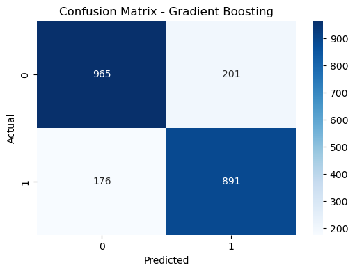

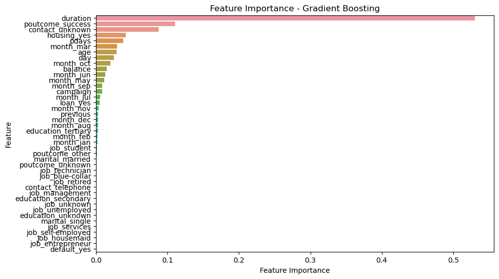

```python
from sklearn.metrics import confusion_matrix
import seaborn as sns

preds = gradient_boosting.predict(X_test)
cm = confusion_matrix(y_test, preds)

plt.figure(figsize=(6, 4))
sns.heatmap(cm, annot=True, cmap='Blues', fmt='d')
plt.xlabel('Predicted')
plt.ylabel('Actual')
plt.title('Confusion Matrix - Gradient Boosting')
plt.show()

feature_importances = gradient_boosting.feature_importances_
feature_names = X.columns

feature_importance_df = pd.DataFrame({'Feature': feature_names, 'Importance': feature_importances})
feature_importance_df = feature_importance_df.sort_values('Importance', ascending=False)

plt.figure(figsize=(10, 6))
sns.barplot(x='Importance', y='Feature', data=feature_importance_df)
plt.xlabel('Feature Importance')
plt.ylabel('Feature')
plt.title('Feature Importance - Gradient Boosting')
plt.show()
```

- Support Vector Machines (SVM)

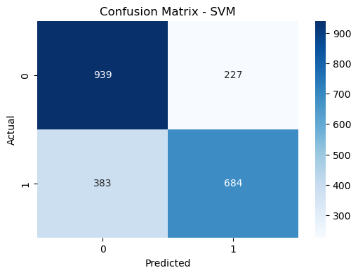

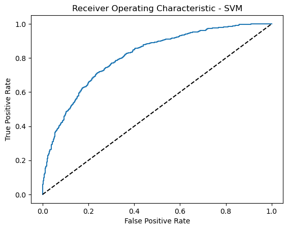

```python
from sklearn.metrics import confusion_matrix
import seaborn as sns

preds = support_vector_machine.predict(X_test)
cm = confusion_matrix(y_test, preds)

plt.figure(figsize=(6, 4))
sns.heatmap(cm, annot=True, cmap='Blues', fmt='d')
plt.xlabel('Predicted')
plt.ylabel('Actual')
plt.title('Confusion Matrix - SVM')
plt.show()

from sklearn.metrics import roc_curve

preds = support_vector_machine.decision_function(X_test)  # Distance to the hyperplane
fpr, tpr, thresholds = roc_curve(y_test, preds)

plt.plot(fpr, tpr)
plt.plot([0, 1], [0, 1], 'k--')  # Diagonal line for random classifier
plt.xlabel('False Positive Rate')
plt.ylabel('True Positive Rate')
plt.title('Receiver Operating Characteristic - SVM')
plt.show()
```

## Model Fine-tuning

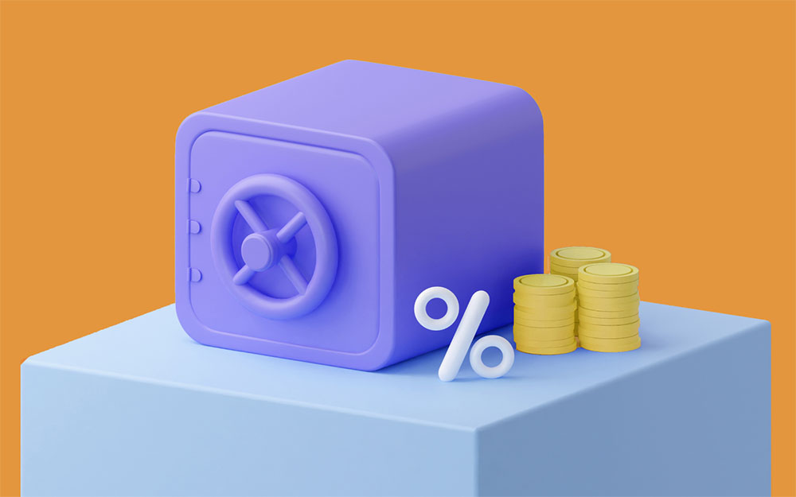

```python
Image("G:/ML portfolio projects/Own Projects\Predicting Term Deposit Suscriptions/8.jpg")
```

- Import the necessary libraries

```python
from sklearn.model_selection import GridSearchCV, RandomizedSearchCV
```

- Define the parameter grid for hyperparameter tuning: For Random Forest

```python
param_grid_rf = {
    'n_estimators': [100, 200, 300],
    'max_depth': [None, 5, 10],
    'min_samples_split': [2, 5, 10],
    'min_samples_leaf': [1, 2, 4],
    'max_features': ['sqrt', 'log2'],
}
```

- Perform hyperparameter tuning using grid search or random search: For Random Forest

```python
rf_grid_search = GridSearchCV(estimator=random_forest, param_grid=param_grid_rf, scoring='accuracy', cv=5)
rf_grid_search.fit(X_train, y_train)
best_rf_model = rf_grid_search.best_estimator_
```

- Get the best hyperparameters and retrain the models: For Random Forest

```python
print("Best Random Forest Model:")
print(best_rf_model)
best_rf_model.fit(X_train, y_train)
```

```
Best Random Forest Model:
RandomForestClassifier(max_features='log2', min_samples_split=5)
```

```
RandomForestClassifier(max_features='log2', min_samples_split=5)
```

- For Gradient Boosting

```python
param_grid_gb = {
    'n_estimators': [100, 200, 300],
    'learning_rate': [0.01, 0.1, 1],
    'max_depth': [3, 5, 10],
    'min_samples_split': [2, 5, 10],
    'min_samples_leaf': [1, 2, 4],
}
```

- For Gradient Boosting

```python
gb_random_search = RandomizedSearchCV(estimator=gradient_boosting, param_distributions=param_grid_gb, scoring='accuracy', cv=5)
gb_random_search.fit(X_train, y_train)
best_gb_model = gb_random_search.best_estimator_
```

- For Gradient Boosting

```python
print("Best Gradient Boosting Model:")
print(best_gb_model)
best_gb_model.fit(X_train, y_train)
```

```
Best Gradient Boosting Model:
GradientBoostingClassifier(min_samples_leaf=2, n_estimators=300)
```

```
GradientBoostingClassifier(min_samples_leaf=2, n_estimators=300)
```

- Make predictions on the test set using the retrained models

```python
rf_preds = best_rf_model.predict(X_test)
gb_preds = best_gb_model.predict(X_test)
```

- Evaluate the performance of each model using evaluation metrics

```python
print("Random Forest Metrics:")
print("Accuracy:", accuracy_score(y_test, rf_preds))
print("Precision:", precision_score(y_test, rf_preds))
print("Recall:", recall_score(y_test, rf_preds))
print("F1-Score:", f1_score(y_test, rf_preds))
print("ROC-AUC:", roc_auc_score(y_test, rf_preds))
print("\n")

print("Gradient Boosting Metrics:")
print("Accuracy:", accuracy_score(y_test, gb_preds))
print("Precision:", precision_score(y_test, gb_preds))
print("Recall:", recall_score(y_test, gb_preds))
print("F1-Score:", f1_score(y_test, gb_preds))
print("ROC-AUC:", roc_auc_score(y_test, gb_preds))
```

```
Random Forest Metrics:
Accuracy: 0.8441558441558441
Precision: 0.8139737991266376
Recall: 0.8734770384254921
F1-Score: 0.8426763110307415
ROC-AUC: 0.8454006118371027


Gradient Boosting Metrics:
Accuracy: 0.8441558441558441
Precision: 0.8265213442325159
Recall: 0.8528584817244611
F1-Score: 0.8394833948339483
ROC-AUC: 0.8445252957507383
```

- Compare the models using a bar plot

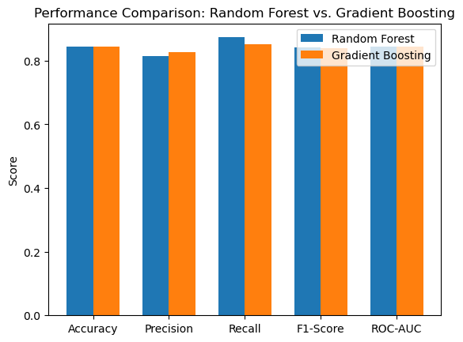

```python
import matplotlib.pyplot as plt

metrics = ['Accuracy', 'Precision', 'Recall', 'F1-Score', 'ROC-AUC']
rf_scores = [accuracy_score(y_test, rf_preds), precision_score(y_test, rf_preds),
             recall_score(y_test, rf_preds), f1_score(y_test, rf_preds), roc_auc_score(y_test, rf_preds)]
gb_scores = [accuracy_score(y_test, gb_preds), precision_score(y_test, gb_preds),
             recall_score(y_test, gb_preds), f1_score(y_test, gb_preds), roc_auc_score(y_test, gb_preds)]

x = range(len(metrics))
width = 0.35

fig, ax = plt.subplots()
ax.bar(x, rf_scores, width, label='Random Forest')
ax.bar([i + width for i in x], gb_scores, width, label='Gradient Boosting')

ax.set_ylabel('Score')
ax.set_title('Performance Comparison: Random Forest vs. Gradient Boosting')
ax.set_xticks([i + width/2 for i in x])
ax.set_xticklabels(metrics)
ax.legend()

plt.show()
```

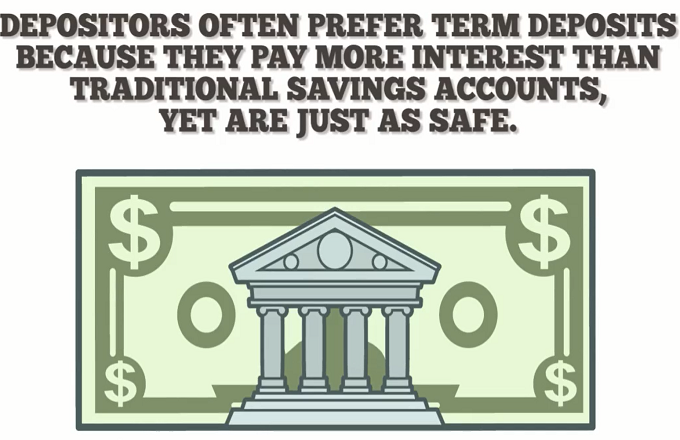

```python
Image("G:/ML portfolio projects/Own Projects\Predicting Term Deposit Suscriptions/2.png")
```